# MSSQL Connection

Para conectarse con el servidor MSSQL se usa la libreria *R ODBC*. Para importar, correr:

```r
library(RODBC)
```

Crear y correr la cadena de conexión:

```r
dbhandle <- odbcDriverConnect('Driver={ODBC Driver 13 for SQL Server};Server=tcp:centaurus-db.database.windows.net,1433;\
            Database=centaurus;Uid=centaurus@centaurus-db;Pwd=k9Rjm7g8V7dh;Encrypt=yes;Connection Timeout=90;')
```

Utilizar `sqlQuery` para correr consultas utilizando la cadena de conexión como el primer parametro y una cadena con la consulta como el segundo parametro:

```r
res <- sqlQuery(dbhandle, 'select * from data where month = 1')
```

El resultado de una consulta será un `data.frame`, dicho df se puede acceder con coordenadas o llaves:

```r
res[1, "abstract"] # Print the title of the first element
```

```
[1] In a Web Advertising Traffic Operation it's necessary to manage the\nday-to-day trafficking, pacing and optimization of digital and paid social\ncampaigns. The data analyst on Traffic Operation can not only quickly provide\nanswers but also speaks the language of the Process Manager and visually…
28404 Levels: -We have performed a new efficient method to calculate numerically the\ntransport coefficients at high temperature. The collision theory was treated to\nstudy singularities that occur when evaluating the collision cross section. The\ntransport coefficients (viscosity, diffusion coeffic…
```

```r
res$abstract <- gsub('\n', ' ', res$abstract)
```

Las llaves posibles son:

```r
colnames(res)
```

```
[1] "id"       "title"    "authors"  "abstract" "url"      "year"     "month"
```

# Tidy Text

Antes de analizar el texto, se deberá cumplir con ciertos criterios o estandares para el analisis de los datos. La estructura requeria es:

- Cada variable es una columna
- Cada observación es una fila
- Cada tipo de observación es una tabla

Iniciamos separando un abstract en un vector separados por la nueva linea “”. La variable “abs_split” es un vector de carácter típico que podríamos querer analizar. Para convertirlo en un conjunto de datos de texto ordenado, primero tenemos que ponerlo en un data frame.

```r
#abstract
#abs_split <- strsplit(abstract, "\n")
#abs_split[[1]]
```

Importamos la libreria “dplyr”, una herramienta rápida y consistente para trabajar con datos como objetos, Tanto en memoria como fuera de memoria. Finalmente creamos un data frame nuevo con el vector creado anteriormente.

```r
library(dplyr)
text_df <- data_frame(line = res$id, text = res$abstract)
text_df
```

| line | text |
| --- | --- |
| 40 | In a Web Advertising Traffic Operation it's necessary to manage the day-to-day trafficking, pacing and optimization of digital and paid social campaigns. The data analyst on Traffic Operation can not … |
| 41 | We observed a nearby millisecond pulsar J2124-3358 with the Hubble Space Telescope in broad far-UV (FUV) and optical filters. The pulsar is detected in both bands with fluxes F(1250-2000 A)= (2.5+/-0.… |
| 42 | We revisit the relation between the stellar surface density, the gas surface density, and the gas-phase metallicity of typical disk galaxies in the local Universe with the SDSS-IV/MaNGA survey, using … |
| 43 | A number of proposals with differing predictions (e.g. Borel group cohomology, oriented cobordism, group supercohomology, spin cobordism, etc.) have been made for the classification of symmetry protec… |
| 44 | A simple, model-independent method to quantify the stochastic variability of active galactic nuclei (AGNs) is the structure function (SF) analysis. If the SF for the timescales shorter than the decorr… |
| 45 | We show that in D=2n+1 dimensions, when mass is negative and all angular momenta are non-vanishing, Kerr and Kerr-AdS metrics describe smooth time machines, with no curvature singularity. Turning off … |
| 46 | It is well known that there is a particle-hole symmetry for spin-polarized electrons with two-body interactions in a partially filled Landau level, which becomes exact in the limit where the cyclotron… |
| 47 | We introduce a new method for time-domain signal processing, based on deep learning neural networks, which has the potential to revolutionize data analysis in engineering and science. To demonstrate h… |
| 48 | The Faddeev--Popov rules for gauge theories with a gauge group are generalized to the case of invariance for the quantum action under $3$-parametric Abelian SUSY transformations with odd-valued parame… |
| 49 | We present the first calculation of the shear viscosity for two-flavor plane wave (FF) color superconducting quark matter. This is a member of the family of crystalline color superconducting phases of… |

[output cut: 990 more lines]

Cada linea de este data frame simboliza un abstract entero, para este ejemplo usaremos cada linea como un abstract separado.

Importamos la libreria “tidytext”. Ahora, creamos un nuevo data frame separando cada palabra en un token nuevo.

```r
library(tidytext)
 words <- text_df %>%
  unnest_tokens(word, text)
 words
```

| line | word |
| --- | --- |
| 40 | in |
| 40 | a |
| 40 | web |
| 40 | advertising |
| 40 | traffic |
| 40 | operation |
| 40 | it's |
| 40 | necessary |
| 40 | to |
| 40 | manage |

[output cut: 990 more lines]

Los dos argumentos básicos para unnest_tokens utilizados aquí son nombres de columna. En primer lugar tenemos el nombre de la columna de salida que se creará, ya que el texto no se inserta en él (palabra, en este caso) y, a continuación, la columna de entrada de la que proviene el texto (en este caso, texto). Recuerde que text_df arriba tiene una columna llamada texto que contiene los datos de interés.

Después de usar unnest_tokens, hemos dividido cada fila de manera que haya un token (palabra) en cada fila del nuevo marco de datos; La tokenización predeterminada en unnest_tokens () es para palabras simples, como se muestra aquí. Observe también:

Se conservan otras columnas, como el número de línea de cada palabra. La puntuación ha sido despojada. De forma predeterminada, unnest_tokens () convierte los tokens en minúsculas, lo que los hace más fáciles de comparar o combinar con otros conjuntos de datos. (Utilice el argumento to_lower = FALSE para desactivar este comportamiento). Tener los datos de texto en este formato nos permite manipular, procesar y visualizar el texto utilizando el conjunto estándar de herramientas ordenadas, a saber, dplyr, tidyr y ggplot2, como se muestra en la siguiente figura:

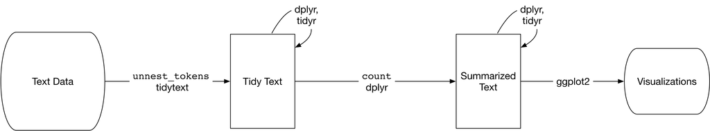

El siguiente paso es eliminar las palabras innecesarias o que no aportan valor a los datos:

```r
data(stop_words)
tidy_abs <- words %>%
  anti_join(stop_words)
tidy_abs
```

| line | word |
| --- | --- |
| 212334 | diseased |
| 201441 | cucr |
| 201441 | fddd |
| 201441 | zncr |
| 201441 | zncr |
| 201441 | zncr |
| 201441 | mgcr |
| 201441 | mgcr |
| 201404 | daehee |
| 201391 | culminate |

[output cut: 990 more lines]

Contamos las palabras repetidas para tener idea de la frecuencia de las palabras:

```r
tidy_abs %>%
  count(word, sort = TRUE)
```

| word | n |
| --- | --- |
| model | 11401 |
| 1 | 10264 |
| 2 | 9329 |
| results | 9162 |
| data | 8593 |
| time | 8366 |
| based | 7648 |
| paper | 7370 |
| field | 7072 |
| study | 6677 |

[output cut: 990 more lines]

Sacamos unas tablas para entender una visión mas clara de la data

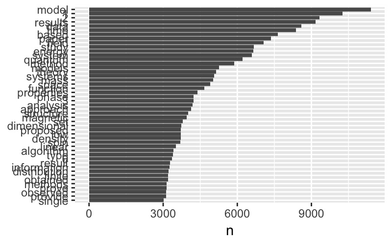

```r
library(ggplot2)
tidy_abs %>%
  count(word, sort = TRUE) %>%
  filter(n > 3000) %>%
  mutate(word = reorder(word, n)) %>%
  ggplot(aes(word, n)) +
  geom_col() +
  xlab(NULL) +
  coord_flip()
```

# Frecuencias de Palabras

En el estudio anterior extrajimos, limpiamos y estudiamos información basica sobre los datos del query `select * from data where month = 1`. Ahora correremos una segunda y tercera consulta a la base de datos:

```r
res2 <- sqlQuery(dbhandle, 'select * from data where month = 2')
res3 <- sqlQuery(dbhandle, 'select * from data where month = 3')
```

Nuevamente limpiaremos los datos:

```r
res2$abstract <- gsub('\n', ' ', res2$abstract)
res3$abstract <- gsub('\n', ' ', res3$abstract)
text_df2 <- data_frame(line = res2$id, text = res2$abstract)
text_df3 <- data_frame(line = res3$id, text = res3$abstract)
words2 <- text_df2 %>%
  unnest_tokens(word, text) %>%
  anti_join(stop_words)
words3 <- text_df3 %>%
  unnest_tokens(word, text) %>%
  anti_join(stop_words)
words2
```

| line | word |
| --- | --- |
| 212331 | 1.0fb |
| 212284 | globalizations |
| 212284 | megrelishvili |
| 212284 | kellendonk |
| 212279 | 3823 |
| 212279 | 3823 |
| 212274 | milligram |
| 212267 | neutrosophic |
| 212253 | computerization |
| 212253 | spacex |

[output cut: 990 more lines]

[output not shown]

[output cut: 990 more lines]

# Word Frequency Example

```r
library(janeaustenr)
library(dplyr)
library(stringr)

original_books <- austen_books() %>%
  group_by(book) %>%
  mutate(linenumber = row_number(),
         chapter = cumsum(str_detect(text, regex("^chapter [\\divxlc]",
                                                 ignore_case = TRUE)))) %>%
  ungroup()

original_books
```

```r
library(tidytext)
tidy_books <- original_books %>%
  unnest_tokens(word, text)

tidy_books
```

```r
data(stop_words)

tidy_books <- tidy_books %>%
  anti_join(stop_words)
```

```r
tidy_books %>%
  count(word, sort = TRUE)
```

```r
library(ggplot2)

tidy_books %>%
  count(word, sort = TRUE) %>%
  filter(n > 600) %>%
  mutate(word = reorder(word, n)) %>%
  ggplot(aes(word, n)) +
  geom_col() +
  xlab(NULL) +
  coord_flip()
```

[output not shown]

```r
library(gutenbergr)

hgwells <- gutenberg_download(c(35, 36, 5230, 159))
```

```r
tidy_hgwells <- hgwells %>%
  unnest_tokens(word, text) %>%
  anti_join(stop_words)
```

```r
tidy_hgwells %>%
  count(word, sort = TRUE)
```

```r
bronte <- gutenberg_download(c(1260, 768, 969, 9182, 767))

tidy_bronte <- bronte %>%
  unnest_tokens(word, text) %>%
  anti_join(stop_words)

tidy_bronte %>%
  count(word, sort = TRUE)
```

```r
library(tidyr)

frequency <- bind_rows(mutate(tidy_bronte, author = "Brontë Sisters"),
                       mutate(tidy_hgwells, author = "H.G. Wells"),
                       mutate(tidy_books, author = "Jane Austen")) %>%
  mutate(word = str_extract(word, "[a-z']+")) %>%
  count(author, word) %>%
  group_by(author) %>%
  mutate(proportion = n / sum(n)) %>%
  select(-n) %>%
  spread(author, proportion) %>%
  gather(author, proportion, `Brontë Sisters`:`H.G. Wells`)

frequency
```

```r
library(scales)

# expect a warning about rows with missing values being removed
ggplot(frequency, aes(x = proportion, y = `Jane Austen`, color = abs(`Jane Austen` - proportion))) +
  geom_abline(color = "gray40", lty = 2) +
  geom_jitter(alpha = 0.1, size = 2.5, width = 0.3, height = 0.3) +
  geom_text(aes(label = word), check_overlap = TRUE, vjust = 1.5) +
  scale_x_log10(labels = percent_format()) +
  scale_y_log10(labels = percent_format()) +
  scale_color_gradient(limits = c(0, 0.001), low = "darkslategray4", high = "gray75") +
  facet_wrap(~author, ncol = 2) +
  theme(legend.position="none") +
  labs(y = "Jane Austen", x = NULL)
```

[output not shown]